# Introduction to deep learning

Benny Avelin

[figure not shown]

By Glosser.ca - Own work, Derivative of File:Artificial neural network.svg, [CC BY-SA 3.0](https://creativecommons.org/licenses/by-sa/3.0), [Link](https://commons.wikimedia.org/w/index.php?curid=24913461)

# Overview (session 4)

- CNNs
- ImageNet challenge and different winners
- Autoencoders
- Reinforcement learning

# There are many different problems that NNs attempt to solve

- Image classification
- Object location
- Natural language processing
- Image restoration
- Fingerprinting

# CNNs

- When images or audio are involved Convolutional Neural Networks are almost exclusively used.
- Convolutional neural networks are an extension of the Neural Networks that we have defined.
- We replace the vector dot-product with linear operators that are discrete convolutional operators.

# CNNs

- Consider an $a \times b$ convolutional kernel (matrix), $K$.
- Consider the input $X$ being $n \times m$ matrix (think image) $$ (K \ast X)_{ij} = \sum_{k=1,l=1}^{a,b} K_{kl} X_{i-k,j-l} $$ for $i = a+1,\ldots, n$, $j=b+1, \ldots, m$.
- This is called `padding=valid` convolution.
- There are dimension preserving convolutions (`padding = same`), this is done by extending $X$ as identically zero.
- For one-dimension (usually time series) there is a `padding=causal`, such that it does not convolve with the future.

# How does this become a network?

- A single artificial neuron can then be represented as $$ h(x) = \sigma(w \cdot x + b) $$
- Replacing the dot-product $w \cdot x$ with the convolution and instead of considering $x \in \mathbb{R}^d$ we consider $X \in \mathbb{R}^{n}\times \mathbb{R}^m$.
- $\sigma$ is applied componentwise as before.

# CNNs

- A single CNN neuron can then be represented as $$ h(x) = \sigma(K \ast X + b) $$ $b$ is a number added to each component.
- But this is single input!
- We define the input dimensions with how many `channels` the input has
- Thus real input has shape $X \in \mathbb{R}^n \times \mathbb{R}^m \times \mathbb{R}^d$.

# Image data

- Image data has this form, the first two coordinates signifies the pixels
- The third coordinate is the `channel`, normally this is the colors, `RGB`, Red, Green, Blue.
- Thus the full definition of a single CNN neuron with $d$ input-channels becomes $$ h(x) = \sigma\left (\sum_{i=1}^d K_i \ast X_i + b \right ) $$ where $X_i$ is the $i$:th channel, and $K_i$ is the $i$:th channel kernel.

# What does the kernels look like?

- AlexNet (Krizhevsky, Sutskever, Hinton, 2012)

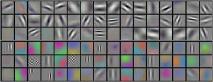

# AlexNet 2012

#### Krizhevsky, Sutskever, Hinton

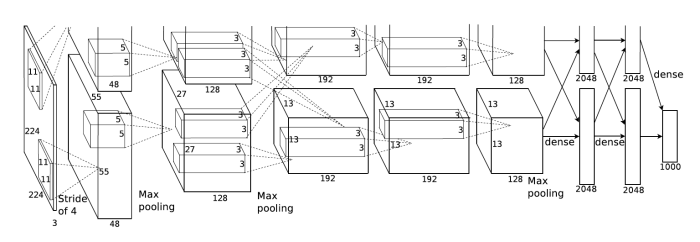

- Considered to be the most influential paper for using GPUs to train deep cnn networks.

# ImageNet Large Scale Visual Recognition Challenge

## (ILSVRC or ImageNet)

- Over 14 Million hand annotated images, more than 20,000 categories.
- Runs each year since 2010.

[figure not shown]

  By Gkrusze - Own work, [CC BY-SA 4.0](https://creativecommons.org/licenses/by-sa/4.0), [Link](https://commons.wikimedia.org/w/index.php?curid=69750373)

# 2014 winner, GoogLeNet

#### Szegedy, Liu, Jia, Sermanet, Reed, Anguelov, Erhan, Vanhoucke, Rabinovich

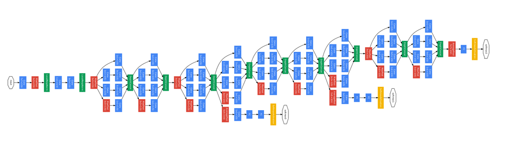

- VGG16 was runner up

# 2015 winner, ResNet

#### He, Zhang, Ren, Sun

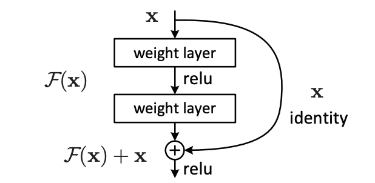

# ResNet

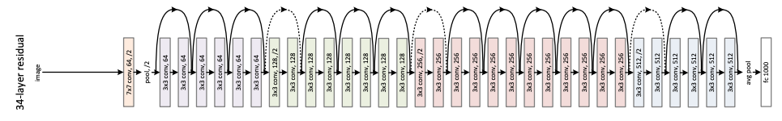

# ResNet

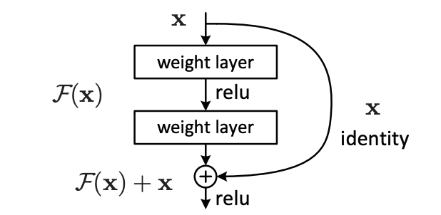

- Call $y_{n-1}$ as the input
- Call $\mathcal{F}$ as the `weight+relu+weight`
- Call $\sigma$ the ReLU $$ y_n = \sigma (y_{n-1} + \mathcal{F}(y_{n-1})) $$

# ResNet

- this is almost a discrete ODE, lets remove the outer ReLU $$ y_n-y_{n-1} = \mathcal{F}(y_{n-1}) $$
- Euler discretization of the ODE $$ \dot{y_t} = \mathcal{F}(y_t) $$

# NeuralODEs (2018)

#### Chen, Rubanova, Bettencourt, Duvenaud

$$ \dot{y_t} = f(y_t,t,\theta) $$

- $f$ is the network
- $y$ is the ODE solution
- $\theta$ are the parameters
- Problem is that if we discretize this and want to compute the gradient, the memory requirements scales with the number of time steps!
- Their idea, use an adjoint ODE to compute the gradient of the loss, constant memory req.

# Autoencoders

[figure not shown]

By Chervinskii - Own work, [CC BY-SA 4.0](https://creativecommons.org/licenses/by-sa/4.0), [Link](https://commons.wikimedia.org/w/index.php?curid=45555552)

# Autoencoders

- Nonlinear "compression" or "projection" or "sparse representation".
- Linear activations or Sigmoid+1 Hidden -> strong correlation to PCA, (Plaut, 2018)

> "The weights of an autoencoder with a single hidden layer of size $p$ (where $p$ is less than the size of the input) span the same vector subspace as the one spanned by the first $p$ principal components, and the output of the autoencoder is an orthogonal projection onto this subspace."

# Autoencoders

- Denoising Autoencoder (can be used for fingerprinting)
- Sparse Autoencoder (Large hidden layer but sparse penalization)
- Variational Autoencoder (Variational Bayesian approach, approximates the posterior, strong assumptions)

# Reinforcement learning

- In its basic form its modeled as a *Markov decision process*
- Environment and agent state $S$
- $P_a(s,s') = P(s_{t+1}=s' | s_t = s, a_t = a)>0$, transition probabilities
- $R_a(s,s')$ immediate reward from being in state $s$ taking action $a$ and ending up in state $s'$.
- $\pi: S \to A$ the policy

[figure not shown]

By Megajuice - Own work, [CC0](http://creativecommons.org/publicdomain/zero/1.0/deed.en), [Link](https://commons.wikimedia.org/w/index.php?curid=57895741)

# Q-Learning (Watkins 1989)

- In Q-Learning we do not know the transition probabilities so we need to experiment and learn it from experimentation.

$$ V^\pi(s) = \mathbb{E} \left [ \sum_{t} \gamma^t R_{\pi(s_t)}(s_t,s_{t+1}) \right ], \quad s_0=s $$

given $s_t$ we know that $s_{t+1}$ is a random variable with distribution $P_{\pi(s_t)}(s_t,\cdot)$, and $\gamma < 1$ is a discount factor.

- For a given policy the sequence of states $s_t$ starting in $s$ is a Markov process.

# Q-Learning

$$ V^\ast(s) = \max_{\pi} V^{\pi}(s) $$

We define for a given $s$ and $a$, $$ Q^\ast(s,a) = \max_\pi Q^\pi(s,a) $$ where $Q^\pi(s,a)$ is the expected reward starting at $s$ taking action $a$ and then following $\pi$.

$$ V^\ast(s) = \max_a Q^\ast(s,a) $$

The Bellman equation for MDPs states that $$ Q^\ast(s,a) = \mathbb{E}_{s' \sim P_a(s,\cdot)}[R_a(s,s') + \gamma \max_{a'} Q^\ast(s',a')] $$ where $s'$ is the state reached after taking action $a$ in state $s$.

- Note the policy depends on the starting position $s$, but our assumption that the transition probability was positive now removes this dependency.

# Q-Learning

- Start with an initial guess for the function $Q: \mathcal{S} \times \mathcal{A} \to \mathbb{R}$
- Iterate as follows $$\tiny{\displaystyle Q^{new}(s_{t},a_{t})\leftarrow (1-\alpha )\cdot \underbrace {Q(s_{t},a_{t})} _{\text{old value}}+\underbrace {\alpha } _{\text{learning rate}}\cdot \overbrace {{\bigg (}\underbrace {r_{t}} _{\text{reward}}+\underbrace {\gamma } _{\text{discount factor}}\cdot \underbrace {\max _{a}Q(s_{t+1},a)} _{\text{estimate of optimal future value}}{\bigg )}} ^{\text{learned value}}}$$

# Q-Learning

- Q-Learning requires us to keep track of the matrix $Q$ which can be very large is the state and action space is large.

## Neural Q-Learning

- Approximate the $Q$ matrix with a deep neural network
- Works, but the learning problem has too much correlation.

## Deep Q-Learning

- DeepMind used a method called `experience replay` to decorrelate the training examples.

# Notable achievements

- Alpha Go, Learned from expert players then trained against itself.
- Alpha Go Zero, trained entirely by playing against itelf.
- AlphaZero, similar to above but better and general, can play several games.
- DeepMind, Playing Atari with Deep Reinforcement Learning (2013)

# Next session

- ?